# Linear Models: Multiple Categories

## Hierarchy of GLMs

[figure not shown]

## Problem

[figure not shown]

## Prediction

> Outcome: Juvenile Survival

Possible predictors:

- Birth date
- Birth mass
- Year
- Sex
- Maternal fecundity
- Maternal reproductive status
- Maternal age
- Population size
- Temperature (min, max, ave…)
- Rainfall
- Wind speed
- …

## Prediction with categorical variables

We have done prediction with only two groups (levels)

- Are the means different?
- Horned lizards example

Now predict with three or more groups

- Is *at least* one mean different?
- Then, *which* mean(s) is/are different

## Does bright light treatment alleviate jet lag symptoms?

[figure not shown]

- 3 groups
- No light (control)
- Bright light in eyes
- Bright light in knees
- Outcome
- Shift in circadian pattern (hours)

## ANOVA

A more general version of a two-sample *t*-test for *k* groups:

- H<sub>0</sub>: \(\mu_{1}=\mu_{2}=\mu_{3}\dots=\mu_{k}\)
- H<sub>A</sub>: At least one mean is different (but we won’t know which yet)

One-way ANOVA: a single categorical variable

- We will generalize to more variables later

## “Analysis of Variance”

Some total variability in *Y*:

1. Part explained by group membership
2. Part remains unexplained (“error” or “residual”)

\(F\)-statistic is the ratio of the two.

## Assumptions of ANOVA

1. The measurments in every group represent a random sample from the corresponding population
2. The variable is normally distributed in each population
3. The variance is the same in all populations
- ANOVA is very robust to violations of these assumptions
- Central limit theorem!
- Equal sample sizes helps with violations of equal variances
- ANOVA is the *Maximum Likelihood Solution* given these assumptions

## Does bright light treatment alleviate jet lag symptoms?

[figure not shown]

- 3 groups
- No light (control)
- Bright light in eyes
- Bright light in knees
- Outcome
- Shift in circadian pattern (hours)

## Does bright light treatment alleviate jet lag symptoms?

```r
JL <- read_csv("../data/JetLag.csv") %>%
  mutate(Treatment = factor(Treatment))
```

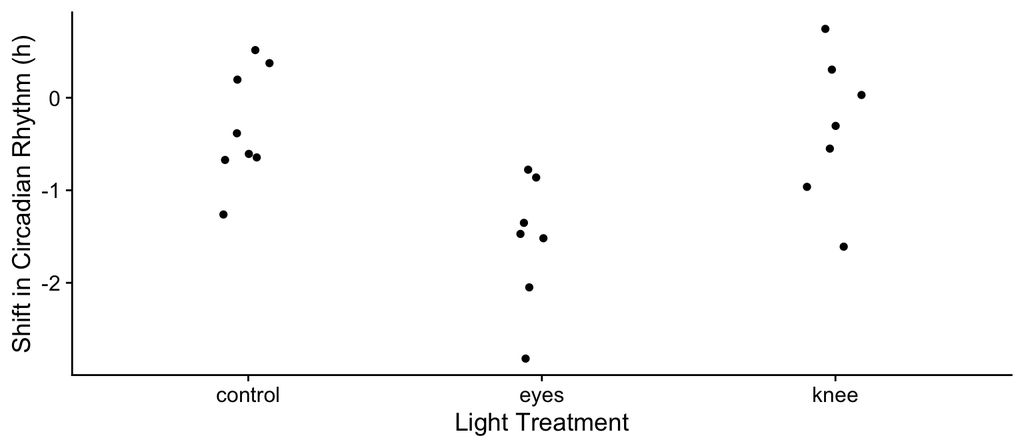

## Compare group means and standard deviations

```r
JL %>% group_by(Treatment) %>%
  summarise(mean(Shift), sd(Shift),
            .groups = "drop")
```

```
## # A tibble: 3 x 3
##   Treatment `mean(Shift)` `sd(Shift)`
##   <fct>             <dbl>       <dbl>
## 1 control          -0.309       0.618
## 2 eyes             -1.55        0.706
## 3 knee             -0.336       0.791
```

## Compare group means and standard errors

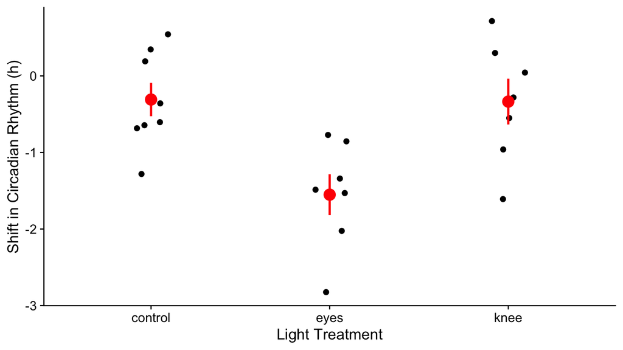

## ANOVA as a Linear Model

```r
fm_lm <- lm(Shift ~ Treatment, data = JL)
summary(fm_lm)
```

```
##
## Call:
## lm(formula = Shift ~ Treatment, data = JL)
##
## Residuals:
##      Min       1Q   Median       3Q      Max
## -1.27857 -0.36125  0.03857  0.61147  1.06571
##
## Coefficients:
##               Estimate Std. Error t value Pr(>|t|)
## (Intercept)   -0.30875    0.24888  -1.241  0.22988
## Treatmenteyes -1.24268    0.36433  -3.411  0.00293 **
## Treatmentknee -0.02696    0.36433  -0.074  0.94178
## ---
## Signif. codes:  0 '***' 0.001 '**' 0.01 '*' 0.05 '.' 0.1 ' ' 1
##
## Residual standard error: 0.7039 on 19 degrees of freedom
## Multiple R-squared:  0.4342, Adjusted R-squared:  0.3746
## F-statistic: 7.289 on 2 and 19 DF,  p-value: 0.004472
```

## Parameter estimates

```
## Coefficients:
##               Estimate Std. Error t value Pr(>|t|)
## (Intercept)   -0.30875    0.24888  -1.241  0.22988
## Treatmenteyes -1.24268    0.36433  -3.411  0.00293
## Treatmentknee -0.02696    0.36433  -0.074  0.94178
```

1. `(Intercept)`: Mean for 1st level of factor
2. `Treatmenteyes`: Adjustment from `(Intercept)` for eyes group (`Intercept` + `Treatmenteyes`)
3. `Treatmentknee`: Adjustment from `(Intercept)` for knee group (`Intercept` + `Treatmentknee`)

*t*-tests and *P* values are suggestive of significant differences, but we need to look at the overall ANOVA first.

## ANOVA table from a Linear Model

```r
anova(fm_lm)
```

```
## Analysis of Variance Table
##
## Response: Shift
##           Df Sum Sq Mean Sq F value   Pr(>F)
## Treatment  2 7.2245  3.6122  7.2894 0.004472 **
## Residuals 19 9.4153  0.4955
## ---
## Signif. codes:  0 '***' 0.001 '**' 0.01 '*' 0.05 '.' 0.1 ' ' 1
```

*P* = 0.004 for the overall ANOVA.

It is possible to have a significant parameter estimate and a non-significant overall ANOVA.

- Nothing more to do.
- No post hoc test

## Visualizing ANOVA

[figure not shown]

\[F = \frac{\mbox{Between Group Variation}}{\mbox{Within Group Variation}}\]

## Model Matrix

```r
fm_lm <- lm(Shift ~ Treatment, data = JL)
```

`model.matrix()` will give you the model for the predictors

```
##    Shift (Intercept) Treatmenteyes Treatmentknee Category
## 1   0.36           1             0             0  control
## 2   0.03           1             0             1     knee
## 3  -1.61           1             0             1     knee
## 4  -2.04           1             1             0     eyes
## 5   0.73           1             0             1     knee
## 6  -0.68           1             0             0  control
## 7  -0.86           1             1             0     eyes
## 8   0.20           1             0             0  control
## 9  -1.52           1             1             0     eyes
## 10 -0.64           1             0             0  control
## 11  0.31           1             0             1     knee
## 12 -0.60           1             0             0  control
## 13 -0.29           1             0             1     knee
## 14 -1.48           1             1             0     eyes
## 15 -1.27           1             0             0  control
## 16 -0.96           1             0             1     knee
## 17  0.53           1             0             0  control
## 18 -0.37           1             0             0  control
## 19 -0.78           1             1             0     eyes
## 20 -2.83           1             1             0     eyes
## 21 -0.56           1             0             1     knee
## 22 -1.35           1             1             0     eyes
```

## *F* distribution

Two different degrees of freedom:

- Numerator: *k* groups - 1
- Denominator: *N* - *k*

```
## # A tibble: 3 x 2
##   Treatment     n
##   <fct>     <int>
## 1 control       8
## 2 eyes          7
## 3 knee          7
```

## Shape of the *F*-distribution

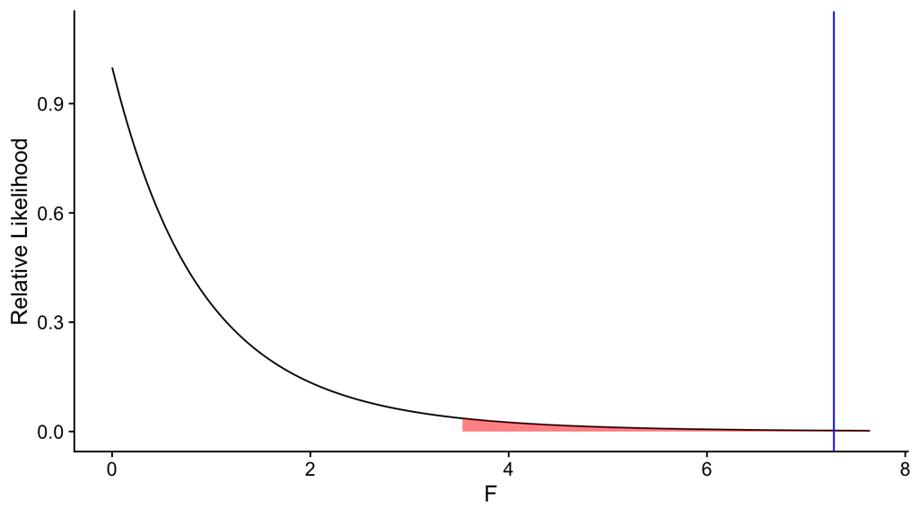

```r
shade_F(0.05, df1 = 2, df2 = 19, vline = 7.28) +
  geom_vline(xintercept = 7.28, color = "blue")
```

## Parts of an ANOVA table

```
## Analysis of Variance Table
##
## Response: Shift
##           Df Sum Sq Mean Sq F value   Pr(>F)
## Treatment  2 7.2245  3.6122  7.2894 0.004472 **
## Residuals 19 9.4153  0.4955
## ---
## Signif. codes:  0 '***' 0.001 '**' 0.01 '*' 0.05 '.' 0.1 ' ' 1
```

- `Sum Sq`: Variability accounted for by that part of the ANOVA
- `Mean Sq`: `Sum Sq` / `Df`
- `F value`: `Mean Sq` Treatment / `Mean Sq` Residual
- `Pr(>F)`: *P*-value for the *F*-test of that variable

## Role of variation

Large values of \(F\) are more likely to be significant.

\(F\) is a ratio:

\[F = \frac{\mbox{MS}_{group}}{\mbox{MS}_{error}}\]

What role does within vs. between group variation have in determining \(F\)?

## If you perfomed pairwise t-tests for all pairs of groups, how often would you expect to get a significant result by chance?

## If you perfomed pairwise t-tests for all pairs of groups, how often would you expect to get a significant result by chance?

- 1 out of every 20 tests
- \(\alpha\) for a single comparison?
- \(\alpha\) for a single test?
- \(\alpha\) for an experiment?
- What do you feel comfortable with?

*Stay tuned for multiple comparisons*

## Post hoc tests for ANOVA

Significant ANOVA (*P* = 0.004) only says that at least one mean is different.

Many options are available for post hoc (unplanned) comparisons:

- Scheffé test
- Duncan’s multiple range test
- Fisher’s least significant difference test
- Newman-Keuls test
- Tukey-Kramer test (Tukey’s Honestly Significant Difference)

We’ll use the Tukey-Kramer test (only one you need to know right now)

## Tukey-Kramer test

- Assumes that we have already performed an ANOVA and rejected the null hypothesis
- If the overall ANOVA is not significant, then a post hoc test makes no sense.
- The familywise error rate (FWER) with a Tukey-Kramer test is no larger than \(\alpha\).
- FWER is the overall probability of a Type I error
- Tukey-Kramer test makes all the same assumptions as ANOVA.
- Defaults to all pairwise combinations of levels

## Tukey-Kramer test: `multcomp` library

- Alternative but less general: `TukeyHSD()` in R
- Only takes an object from `aov()`

```r
tukey <- glht(fm_lm, linfct = mcp(Treatment = "Tukey"))
summary(tukey)
```

```
##
##   Simultaneous Tests for General Linear Hypotheses
##
## Multiple Comparisons of Means: Tukey Contrasts
##
##
## Fit: lm(formula = Shift ~ Treatment, data = JL)
##
## Linear Hypotheses:
##                     Estimate Std. Error t value Pr(>|t|)
## eyes - control == 0 -1.24268    0.36433  -3.411   0.0079 **
## knee - control == 0 -0.02696    0.36433  -0.074   0.9970
## knee - eyes == 0     1.21571    0.37628   3.231   0.0117 *
## ---
## Signif. codes:  0 '***' 0.001 '**' 0.01 '*' 0.05 '.' 0.1 ' ' 1
## (Adjusted p values reported -- single-step method)
```

## Selective Set of Comparisons

```r
post_hoc <- glht(fm_lm,
                 mcp(Treatment = c("eyes - control = 0",
                                   "knee - control = 0")))
summary(post_hoc)
```

```
##
##   Simultaneous Tests for General Linear Hypotheses
##
## Multiple Comparisons of Means: User-defined Contrasts
##
##
## Fit: lm(formula = Shift ~ Treatment, data = JL)
##
## Linear Hypotheses:
##                     Estimate Std. Error t value Pr(>|t|)
## eyes - control == 0 -1.24268    0.36433  -3.411  0.00559 **
## knee - control == 0 -0.02696    0.36433  -0.074  0.99607
## ---
## Signif. codes:  0 '***' 0.001 '**' 0.01 '*' 0.05 '.' 0.1 ' ' 1
## (Adjusted p values reported -- single-step method)
```